# 05. Transfer Learning with TensorFlow Part 2: Fine-tuning

Our previous section saw how our transfer learning was able to learn so well on such little training data. This time, we'll be checking out the fine tuning option.

We will be tweaking the model's layer by unfreezing a few layers from the top (typically 1 to 3 layers), and allow it train and change based on the problem we're working with. Then continue working our way down the model.

### What we're covering

We're going to go through the follow with TensorFlow:

- Introduce fine-tuning, a type of transfer learning to modify a pre-trained model to be more suited to your data
- Using the Keras Functional API (a different way to build models in Keras)
- Using a smaller dataset to experiment faster (e.g. 1-10% of training smaples of 10 classes of food)
- Data augmentation (how to make your dataset more diverse without adding more data)
- Running a series of modelling experiments on our Food Vision data
  - **Model 0**: a transfer learning model using the Keras Functional API
  - **Model 1**: a feature extraction transfer learning model on 1% of the data with data augmentation
  - **Model 2**: a feature extraction transfer learning model on 10% of the data with data augmentation
  - **Model 3**: a fine-tuned transfer learning model on 10% of the data
  - **Model 4**: a fine-tuned transfer learninbg model on 100% of the data
- Introduce the ModelCheckpoint callback to save intermediate training results
- Compare model experiment results using TensorBoard

```python
import datetime
print(f'Notebook last run (end-to-end): {datetime.datetime.now()}')
```

```
Notebook last run (end-to-end): 2025-09-14 13:10:33.836532
```

```python
import tensorflow as tf

print(f'TensorFlow version: {tf.__version__}')
```

```
TensorFlow version: 2.20.0
```

```python
!nvidia-smi
```

[output not shown]

```python
# Install it first if you haven't
!pip install scikit-learn
```

[output not shown]

[output cut: 119 more lines]

[output not shown]

```python
# get helper_functions.py script from course Github
!curl -O https://raw.githubusercontent.com/mrdbourke/tensorflow-deep-learning/main/extras/helper_functions.py

# import helper functions we're going to use
import sys, os
sys.path.append(os.getcwd())
import sklearn


from helper_functions import create_tensorboard_callback, plot_loss_curves, unzip_data, walk_through_dir
```

```
  % Total    % Received % Xferd  Average Speed   Time    Time     Time  Current
                                 Dload  Upload   Total   Spent    Left  Speed

  0     0    0     0    0     0      0      0 --:--:-- --:--:-- --:--:--     0
100 10246  100 10246    0     0  34740      0 --:--:-- --:--:-- --:--:-- 35089
```

Now we've got a bunch of helper functions, we can call the functions rather than rewriting from scratch.

### 10 Food Classes: Working with Less Data

We saw how 10% of data can still train up an effective model. In this notebook, we're still continuing with the same method but with even smaller data sets, whilst using pretrained models from `tf.keras.applications` modules, but also fine-tune them.

We'll also practice use of a dataloader function called `image_dataset_from_directory()`, which is part of `tf.keras.utils` module.

Finally, we will also play with the `Keras Functional API` for building deep learning models. It's a more flexible way to create models than the `tf.keras.Sequential` API.

We'll explore each of these in more detail as we go. But let's start with downloading some data.

Let's check out the 10% food data of 10 by checking it's directories.

```python
# walk through 10 percent data directory of 10 classes of food
walk_through_dir('10_food_classes_10_percent')
```

```
There are 2 directories and 0 images in '10_food_classes_10_percent'.
There are 10 directories and 0 images in '10_food_classes_10_percent\test'.
There are 0 directories and 250 images in '10_food_classes_10_percent\test\ice_cream'.
There are 0 directories and 250 images in '10_food_classes_10_percent\test\chicken_curry'.
There are 0 directories and 250 images in '10_food_classes_10_percent\test\steak'.
There are 0 directories and 250 images in '10_food_classes_10_percent\test\sushi'.
There are 0 directories and 250 images in '10_food_classes_10_percent\test\chicken_wings'.
There are 0 directories and 250 images in '10_food_classes_10_percent\test\grilled_salmon'.
There are 0 directories and 250 images in '10_food_classes_10_percent\test\hamburger'.
There are 0 directories and 250 images in '10_food_classes_10_percent\test\pizza'.
There are 0 directories and 250 images in '10_food_classes_10_percent\test\ramen'.
There are 0 directories and 250 images in '10_food_classes_10_percent\test\fried_rice'.
There are 10 directories and 0 images in '10_food_classes_10_percent\train'.
There are 0 directories and 75 images in '10_food_classes_10_percent\train\ice_cream'.
There are 0 directories and 75 images in '10_food_classes_10_percent\train\chicken_curry'.
There are 0 directories and 75 images in '10_food_classes_10_percent\train\steak'.
There are 0 directories and 75 images in '10_food_classes_10_percent\train\sushi'.
There are 0 directories and 75 images in '10_food_classes_10_percent\train\chicken_wings'.
There are 0 directories and 75 images in '10_food_classes_10_percent\train\grilled_salmon'.
There are 0 directories and 75 images in '10_food_classes_10_percent\train\hamburger'.
There are 0 directories and 75 images in '10_food_classes_10_percent\train\pizza'.
There are 0 directories and 75 images in '10_food_classes_10_percent\train\ramen'.
There are 0 directories and 75 images in '10_food_classes_10_percent\train\fried_rice'.
```

We can see the 10% data, represented by 75 images towards each class, while test remains the same at 250 results per class.

Let's define our training and test filepaths.

```python
# create training and test directories
train_dir = '10_food_classes_10_percent/train/'
test_dir = '10_food_classes_10_percent/test/'
```

With our image data, we need to find ways to load it into TensorFlow compatible format. We used `ImageDataGenerator` for this, but has been legacy. Making it not ideal for future model builds.

We will move onto `tf.keras.utils.image_dataset_from_directory()`, which expects the following directory format:

```
10_food_classes_10_percent <- top level folder
└───train <- training images
│   └───pizza
│   │   │   1008104.jpg
│   │   │   1638227.jpg
│   │   │   ...
│   └───steak
│       │   1000205.jpg
│       │   1647351.jpg
│       │   ...
│
└───test <- testing images
│   └───pizza
│   │   │   1001116.jpg
│   │   │   1507019.jpg
│   │   │   ...
│   └───steak
│       │   100274.jpg
│       │   1653815.jpg
│       │   ...
```

The benefits of using `tf.keras.utils.image_dataset_from_directory()` rather than `ImageDataGenerator` - is it creates `tf.data.Dataset` object rather than a generator.

So what is `tf.data.Dataset`? Its an API which is much more efficient and faster than the API generated from `ImageDataGenerator`.

APIs are a set of tools, functions, and rules that allow you to interact with a library/software. Basically its a way for you to 'talk to' a software and use it's functionality, whilst not needing to know everything about the software.

It's this communication from `tf.data.Dataset` that makes it so much faster, as it loads data in parallel with each other in TensorFlow. Contrasting the other, that loads one by one from using a python generator.

```python
# create data inputs
import tensorflow as tf

IMG_SIZE = (224,224) # define size
train_data_10_percent = tf.keras.utils.image_dataset_from_directory(directory=train_dir,
                                                                    image_size=IMG_SIZE,
                                                                    label_mode='categorical',
                                                                    batch_size=32)
test_data_10_percent = tf.keras.utils.image_dataset_from_directory(directory=test_dir,
                                                                   image_size=IMG_SIZE,
                                                                   label_mode='categorical')
```

```
Found 750 files belonging to 10 classes.
Found 2500 files belonging to 10 classes.
```

Looks like our dataloader has found the correct number of images in each dataset :)

Now, the main parameters to be concerned of are:

- `directory` - filepath of target directory we're loading images from
- `image_size` - target size of images (height, width)
- `batch_size` - batch size of images we're loading in - (default for in general problems is 32)

```python
# check the training datatype
train_data_10_percent
```

```
<_PrefetchDataset element_spec=(TensorSpec(shape=(None, 224, 224, 3), dtype=tf.float32, name=None), TensorSpec(shape=(None, 10), dtype=tf.float32, name=None))>
```

In the above output:

- `(None, 224, 224, 3)` refers to the tensor shape of our image. `None` > batch size, `224, 224` > height, width, `3` > colour channels (red, green, blue).
- `(None, 10)` refers to the tensor shape of our labels. `None` > batch size, `10` > number of classes in our problem.
- Both image and labels are of datatype `tf.float32`

`batch_size` is set as `None`, as it's only used during model training. Think of it as a simple placeholder, which will be filled withe the `batch_size` parameter of `32`.

With `tf.data.Dataset`, it has benefits of associated methods that come with it, like find the name of classes with the `class_names` attribute.

```python
# check out the class names of our dataset
train_data_10_percent.class_names
```

```
['chicken_curry',
 'chicken_wings',
 'fried_rice',
 'grilled_salmon',
 'hamburger',
 'ice_cream',
 'pizza',
 'ramen',
 'steak',
 'sushi']
```

Or if we wanted to see an example batch of data, we could use the `take()` method.

```python
# see an example batch of data
for images, labels in train_data_10_percent.take(1):
    print(images, labels)
```

[output not shown]

[output cut: 285 more lines]

```
 [0. 1. 0. 0. 0. 0. 0. 0. 0. 0.]
 [0. 0. 1. 0. 0. 0. 0. 0. 0. 0.]
 [0. 0. 0. 0. 0. 0. 0. 0. 0. 1.]
 [0. 0. 1. 0. 0. 0. 0. 0. 0. 0.]
 [0. 0. 0. 0. 0. 0. 0. 0. 0. 1.]
 [0. 0. 0. 0. 0. 0. 0. 0. 0. 1.]
 [0. 0. 0. 0. 0. 0. 0. 0. 0. 1.]
 [0. 0. 0. 0. 0. 1. 0. 0. 0. 0.]
 [0. 1. 0. 0. 0. 0. 0. 0. 0. 0.]
 [0. 0. 0. 0. 1. 0. 0. 0. 0. 0.]
 [0. 1. 0. 0. 0. 0. 0. 0. 0. 0.]
 [0. 0. 0. 0. 0. 0. 0. 1. 0. 0.]
 [0. 0. 0. 0. 0. 0. 1. 0. 0. 0.]
 [0. 0. 0. 0. 0. 0. 0. 1. 0. 0.]
 [0. 0. 1. 0. 0. 0. 0. 0. 0. 0.]], shape=(32, 10), dtype=float32)
```

### Model 0: Building a transfer learning model using the Keras Functional API

To build our model, we will use `tf.keras.applications` module, as it has pretrained models on ImageNet, in addition to Keras Functional API.

Our following steps are:

```
1. Instantiate a pretrained base model object by choosing a target model such as `EfficientNetV2B0` from `tf.keras.applications.efficientnet_v2`, setting the `include_top` parameter to `False`. (We'll create our own top, since our output shape is different from the base model)

2. Set base model's `trainable` attribute to `False` to freeze all the weights in the pretrained model.

3. Define an input layer for our model, what shape of data should our model expect?

4. [Optional] Normalize the inputs to our model if required. Some computer models such as `ResNetV250` require their inputs to be between 0 and 1.
```

> **Note**: `EfficientNet` and `EfficientNetV2` models in `tf.keras.applications` module do not require images to be normalized on input, but many other models do require it.

```
5. Pass the inputs to the base model

6. Pool the outputs of the base mnodel into shape, that's compatible with the output activation layer (Our image is a 3D shape, while our output shape needs to become 1D to match it's shape). This can be done through `average pooling` or `max pooling` at times.

7. Create an output activation layer using `tf.keras.layers.Dense()` with the appropriate activation function and number of neurons.

8. Combine the inputs and outputs layer into a model using `tf.keras.Model()`.

9. Compile the model using the appropriate loss function and choose of optimizer.

10. Fit the model for desired number and of epochs with callbacks.
```

Before we start, let's see it in practice

```python
# 1. create base model with tf.keras.applications
base_model = tf.keras.applications.efficientnet_v2.EfficientNetV2B0(include_top=False)

# 2. Freeze the base model (so the pre-learned patterns remain)
base_model.trainable = False

# 3. Create inputs into the base model
inputs = tf.keras.layers.Input(shape=(224,224,3), name='input_layer')

# 4. [optional] If using ResNet50V2, add this to speed up convergence, remove for EfficientNetV2
# x = tf.keras.layers.experimental.preprocessing.Rescaling(1./255)(inputs)

# 5. Pass the inputs to the base_model (note: using tf.keras.applications, EfficientNetV2 don't have to be normalized)
x = base_model(inputs)

# 6. Average pool the outputs of the base model (aggregate all the most important information, reduce number of computations)
x = tf.keras.layers.GlobalAveragePooling2D(name='global_average_pooling_layer')(x)

# 7. Create the output activation layer
outputs = tf.keras.layers.Dense(10, activation='softmax', name='output_layer')(x)

# 8. Combine the inputs with the outpus into the model
model_0 = tf.keras.Model(inputs,outputs)

# 9. Compile the model
model_0.compile(loss='categorical_crossentropy',
                optimizer=tf.keras.optimizers.Adam(),
                metrics=['accuracy'])

# 10. Fit the model (we use less steps for validation so it's faster)
history_10_percent = model_0.fit(train_data_10_percent,
                                 epochs=5,
                                 steps_per_epoch=len(train_data_10_percent),
                                 validation_data=test_data_10_percent,
                                 # go through less of the validation data so epochs are faster
                                 validation_steps=int(0.25 * len(test_data_10_percent)),
                                 # track our model's training logs for visualization later
                                 callbacks=[create_tensorboard_callback('transfer_learning','10_percent_feature_extract')])
```

```
Saving TensorBoard log files to: transfer_learning/10_percent_feature_extract/20251006-204716
24/24 ━━━━━━━━━━━━━━━━━━━━ 26s 698ms/step - accuracy: 0.4120 - loss: 1.8944 - val_accuracy: 0.7303 - val_loss: 1.2917
24/24 ━━━━━━━━━━━━━━━━━━━━ 13s 564ms/step - accuracy: 0.7400 - loss: 1.1468 - val_accuracy: 0.8224 - val_loss: 0.8740
24/24 ━━━━━━━━━━━━━━━━━━━━ 13s 560ms/step - accuracy: 0.8240 - loss: 0.8384 - val_accuracy: 0.8306 - val_loss: 0.7084
24/24 ━━━━━━━━━━━━━━━━━━━━ 13s 570ms/step - accuracy: 0.8520 - loss: 0.6846 - val_accuracy: 0.8618 - val_loss: 0.6001
24/24 ━━━━━━━━━━━━━━━━━━━━ 14s 584ms/step - accuracy: 0.8707 - loss: 0.5868 - val_accuracy: 0.8635 - val_loss: 0.5423
```

The model has done quite well with only 5 epochs.

Keep in mind, we have used feature extraction transfer learning, similar to what we have done on workbook 04.

We have also used Keras Functional API to build the model over Sequential API. The benefits of either may not seem clear right now, but when you create more sophisticated model, you'll probably want to use Functional API. It's important to have exposure to other ways of building models.

> To see benefits and use cases for Function API vs. Sequential API, check out [TensorFlow Functional API documentation](https://www.tensorflow.org/guide/keras/functional).

We'll check the layers in our transplanted model. We will start with the base.

```python
# check layers in our base model
for layer_number, layer in enumerate(base_model.layers):
    print(layer_number, layer.name)
```

```
0 input_layer_1
1 rescaling_1
2 normalization_1
3 stem_conv
4 stem_bn
5 stem_activation
6 block1a_project_conv
7 block1a_project_bn
8 block1a_project_activation
9 block2a_expand_conv
10 block2a_expand_bn
11 block2a_expand_activation
12 block2a_project_conv
13 block2a_project_bn
14 block2b_expand_conv
```

[output cut: 255 more lines]

It's a lot of layers and would take forever to code it in, yet we can take advantage of transfer learning.

What about a summary of the base model?

```python
base_model.summary()
```

```
Model: "efficientnetv2-b0"
```

```
┏━━━━━━━━━━━━━━━━━━━━━┳━━━━━━━━━━━━━━━━━━━┳━━━━━━━━━━━━┳━━━━━━━━━━━━━━━━━━━┓
┃ Layer (type)        ┃ Output Shape      ┃    Param # ┃ Connected to      ┃
┡━━━━━━━━━━━━━━━━━━━━━╇━━━━━━━━━━━━━━━━━━━╇━━━━━━━━━━━━╇━━━━━━━━━━━━━━━━━━━┩
│ input_layer_1       │ (None, None,      │          0 │ -                 │
│ (InputLayer)        │ None, 3)          │            │                   │
├─────────────────────┼───────────────────┼────────────┼───────────────────┤
│ rescaling_1         │ (None, None,      │          0 │ input_layer_1[0]… │
│ (Rescaling)         │ None, 3)          │            │                   │
├─────────────────────┼───────────────────┼────────────┼───────────────────┤
│ normalization_1     │ (None, None,      │          0 │ rescaling_1[0][0] │
│ (Normalization)     │ None, 3)          │            │                   │
├─────────────────────┼───────────────────┼────────────┼───────────────────┤
│ stem_conv (Conv2D)  │ (None, None,      │        864 │ normalization_1[… │
│                     │ None, 32)         │            │                   │
├─────────────────────┼───────────────────┼────────────┼───────────────────┤
│ stem_bn             │ (None, None,      │        128 │ stem_conv[0][0]   │
│ (BatchNormalizatio… │ None, 32)         │            │                   │
├─────────────────────┼───────────────────┼────────────┼───────────────────┤
│ stem_activation     │ (None, None,      │          0 │ stem_bn[0][0]     │
│ (Activation)        │ None, 32)         │            │                   │
├─────────────────────┼───────────────────┼────────────┼───────────────────┤
│ block1a_project_co… │ (None, None,      │      4,608 │ stem_activation[… │
│ (Conv2D)            │ None, 16)         │            │                   │
├─────────────────────┼───────────────────┼────────────┼───────────────────┤
│ block1a_project_bn  │ (None, None,      │         64 │ block1a_project_… │
│ (BatchNormalizatio… │ None, 16)         │            │                   │
├─────────────────────┼───────────────────┼────────────┼───────────────────┤
│ block1a_project_ac… │ (None, None,      │          0 │ block1a_project_… │
│ (Activation)        │ None, 16)         │            │                   │
├─────────────────────┼───────────────────┼────────────┼───────────────────┤
│ block2a_expand_conv │ (None, None,      │      9,216 │ block1a_project_… │
│ (Conv2D)            │ None, 64)         │            │                   │
├─────────────────────┼───────────────────┼────────────┼───────────────────┤
│ block2a_expand_bn   │ (None, None,      │        256 │ block2a_expand_c… │
│ (BatchNormalizatio… │ None, 64)         │            │                   │
├─────────────────────┼───────────────────┼────────────┼───────────────────┤
│ block2a_expand_act… │ (None, None,      │          0 │ block2a_expand_b… │
│ (Activation)        │ None, 64)         │            │                   │
├─────────────────────┼───────────────────┼────────────┼───────────────────┤
│ block2a_project_co… │ (None, None,      │      2,048 │ block2a_expand_a… │
```

[output cut: 758 more lines]

```
│ block6h_drop        │ (None, None,      │          0 │ block6h_project_… │
│ (Dropout)           │ None, 192)        │            │                   │
├─────────────────────┼───────────────────┼────────────┼───────────────────┤
│ block6h_add (Add)   │ (None, None,      │          0 │ block6h_drop[0][… │
│                     │ None, 192)        │            │ block6g_add[0][0] │
├─────────────────────┼───────────────────┼────────────┼───────────────────┤
│ top_conv (Conv2D)   │ (None, None,      │    245,760 │ block6h_add[0][0] │
│                     │ None, 1280)       │            │                   │
├─────────────────────┼───────────────────┼────────────┼───────────────────┤
│ top_bn              │ (None, None,      │      5,120 │ top_conv[0][0]    │
│ (BatchNormalizatio… │ None, 1280)       │            │                   │
├─────────────────────┼───────────────────┼────────────┼───────────────────┤
│ top_activation      │ (None, None,      │          0 │ top_bn[0][0]      │
│ (Activation)        │ None, 1280)       │            │                   │
└─────────────────────┴───────────────────┴────────────┴───────────────────┘
```

```
 Total params: 5,919,312 (22.58 MB)
```

```
 Trainable params: 0 (0.00 B)
```

```
 Non-trainable params: 5,919,312 (22.58 MB)
```

We can see each different layers and their number of parameters. Since this model is pre-trained, you can think of all of these parameter as patterns the base model has learned on another dataset.

Due to setting `base_model.trainable = False`, these patterns remain as they are during training (they're frozen and don't get updated).

Alright, let's see the summary of overall model.

```python
# Check summary of model constructed with Functional API
model_0.summary()
```

```
Model: "functional"
```

```
┏━━━━━━━━━━━━━━━━━━━━━━━━━━━━━━━━━┳━━━━━━━━━━━━━━━━━━━━━━━━┳━━━━━━━━━━━━━━━┓
┃ Layer (type)                    ┃ Output Shape           ┃       Param # ┃
┡━━━━━━━━━━━━━━━━━━━━━━━━━━━━━━━━━╇━━━━━━━━━━━━━━━━━━━━━━━━╇━━━━━━━━━━━━━━━┩
│ input_layer (InputLayer)        │ (None, 224, 224, 3)    │             0 │
├─────────────────────────────────┼────────────────────────┼───────────────┤
│ efficientnetv2-b0 (Functional)  │ (None, 7, 7, 1280)     │     5,919,312 │
├─────────────────────────────────┼────────────────────────┼───────────────┤
│ global_average_pooling_layer    │ (None, 1280)           │             0 │
│ (GlobalAveragePooling2D)        │                        │               │
├─────────────────────────────────┼────────────────────────┼───────────────┤
│ output_layer (Dense)            │ (None, 10)             │        12,810 │
└─────────────────────────────────┴────────────────────────┴───────────────┘
```

```
 Total params: 5,957,744 (22.73 MB)
```

```
 Trainable params: 12,810 (50.04 KB)
```

```
 Non-trainable params: 5,919,312 (22.58 MB)
```

```
 Optimizer params: 25,622 (100.09 KB)
```

You can see the transformation of shape from input of `(None, 224, 224, 3)`, to the output of `(None, 10)`, where `None` is placeholder for batch size.

The only trainable parameters in the model are the output layer.

So how does model training curve look like?

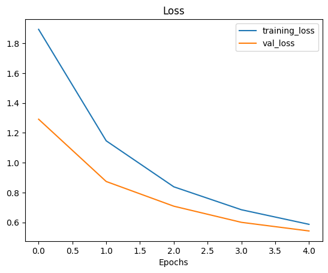

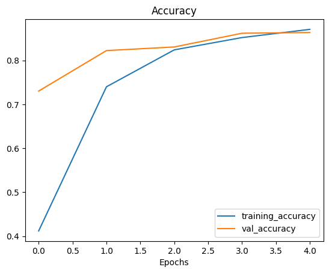

```python
# check out model training curve history
plot_loss_curves(history_10_percent)
```

### Getting a feature vector from a trained model

**What is feature vector?** > It's the second to last layer of the model, aka the layer before the output layer. It's a 1D compact representation of the inputted data (e.g. `(None, 2048)`), before it's classified in the classes of the output layer

> **Question**: What happens with the `tf.keras.GlobalAveragePooling2D()` layer transforms a 4D tensor into a 2D tensor by averaging the values across the inner-axes.

The previous sentence is a bit mouthful, so we'll see this in action.

```python
# Define input tensor shape (same number of dimensions as the output of efficientnetv2-b0)
input_shape = (1,4,4,3)

# Create a random tensor
tf.random.set_seed(35)
input_tensor = tf.random.normal(input_shape)
print(f"Random input tensor:\n {input_tensor}\n")

# Pass the random tensor through a global average pooling 2D layer
global_average_pooled_tensor = tf.keras.layers.GlobalAveragePooling2D()(input_tensor)
print(f'2D global average pooled random tensor:\n {global_average_pooled_tensor}\n')

# Check the shapes of the different tensors
print(f'Shape of input tensor: {input_tensor.shape}')
print(f'Shape of 2D global averaged pooled input tensor: {global_average_pooled_tensor.shape}')
```

```
Random input tensor:
 [[[[ 2.2217767  -0.30146012  1.0177914 ]
   [-1.2843658  -0.16923259 -0.7082916 ]
   [ 0.5628517  -0.9604295  -1.1108632 ]
   [-0.7519864   0.8463829   0.745947  ]]

  [[-0.24670422 -0.9917532   0.5135337 ]
   [-1.7907373  -0.28143376 -0.01009051]
   [-0.67895067 -0.23497029 -1.0445431 ]
   [-0.04763518  1.594667   -0.40636218]]

  [[-1.9090234  -0.87867856 -0.71947384]
   [ 0.04788789  0.2768906   1.1405766 ]
   [ 0.44342762 -0.67578     0.6897585 ]
   [ 1.1216972  -1.0744088   0.182657  ]]

  [[-0.6914823  -0.7301613   0.49244884]
   [-0.39586642  0.89530694 -1.5820867 ]
   [ 0.62116927  0.13989049  1.1740805 ]
   [-0.61668336 -0.7115485  -0.98318386]]]]

2D global average pooled random tensor:
 [[-0.21216401 -0.20354491 -0.03800634]]

Shape of input tensor: (1, 4, 4, 3)
Shape of 2D global averaged pooled input tensor: (1, 3)
```

Average pooling is collapsed into 3, which don't look correct on the display of our tensor shape. What's happening is each [] represents a pixel, and the 3 values in these pixels represent an RGB colour channel.

Therefore R is 1st column, G is 2nd column, and B is 3rd column of the tensor shape.

As we can see, `tf.keras.layers.GlobalAveragePooling2D()` layer condensed the input tensor from shape `(1,4,4,3)` to `(1,3)`. It's done so through averaging `input_tensor` across the (4,4) shape.

This can be replicated using `tf.reduce_mean()` operation and specifying the appropriate axes.

```python
# This is the same as GlobalAveragingPooling2D()
tf.reduce_mean(input_tensor, axis=[1,2]) # average across the middle axes of (4,4) > 1,2 indicating the index of our tensor shape
```

```
<tf.Tensor: shape=(1, 3), dtype=float32, numpy=array([[-0.21216401, -0.20354491, -0.03800634]], dtype=float32)>
```

Doing that, not only makes the output of base model compatible with the input shape requirement of our output layer (`tf.keras.layers.Dense()`), it also condenses the information found by the base model into a lower dimension feature vector.

Aka, average pooling cuts out all the extra work in between, and delivers a 1 dimensional dataset, aka a feature vector, which can be directly used by the output layer for classification purposes.

> **Note**: One of the reasons 'feature extraction transfer learning' is named the way it is, is due to what happens when pretrained model outputs a **feature vector**, that can be used to extract patterns out of.

> **Practice**: Do the same as above but with `tf.keras.layers.GlobalMaxPooling2D()`

```python
global_max_pooling_tensor = tf.keras.layers.GlobalMaxPooling2D()(input_tensor)
print(f'2D global max pooled random tensor:\n {global_max_pooling_tensor}')
```

```
2D global max pooled random tensor:
 [[2.2217767 1.594667  1.1740805]]
```

### Running a series of transfer learning experiments

We've seen incredible results with only 10% of training data. But what about 1%?

We will answer those questions through running the following experiments:

**Model 1**: Use feature extraction transfer learning on 1% of the training data with data augmentation.

**Model 2**: Use feature extraction transfer learning on 10% of the training data with data augmentation and save the results to a checkpoint.

**Model 3**: Fine-tune the Model 2 checkpoint on 10% of the training data with data augmentation.

**Model 4**: Fine-tune the Model 2 checkpoint on 100% of the training data with data augmentation.

All these experiments will run on different versions of the training data, but will all be evaluated with the same testing data, so that way we can compare and contrast.

All experiments are to be done with `EfficientNetV2B0` model.

We'll make sure to use `create_tensorboard_callback()` to log and track our experiments.

We'll construct eachmodel using the Keras Functional API. Instead of implementing data augmentation on `ImageDataGenerator` class, we'll build it into model using `tf.keras.layers` module.

Let's begin by downloading data for experiment 1, using feature extraction transfer learning on 1% of the training data with data augmentation.

```python
# create training and test dirs
train_dir_1_percent = '10_food_classes_1_percent/train/'
test_dir = '10_food_classes_10_percent/test/' # pull the 10% test folder instead, since both dataset uses the same test files regardless
```

Let's look at the number of images we're working with

```python
# walk through 1 percent data directory and list number of files
walk_through_dir('10_food_classes_1_percent'), walk_through_dir('10_food_classes_10_percent/test')
```

```
There are 1 directories and 0 images in '10_food_classes_1_percent'.
There are 10 directories and 0 images in '10_food_classes_1_percent\train'.
There are 0 directories and 7 images in '10_food_classes_1_percent\train\ice_cream'.
There are 0 directories and 7 images in '10_food_classes_1_percent\train\chicken_curry'.
There are 0 directories and 7 images in '10_food_classes_1_percent\train\steak'.
There are 0 directories and 7 images in '10_food_classes_1_percent\train\sushi'.
There are 0 directories and 7 images in '10_food_classes_1_percent\train\chicken_wings'.
There are 0 directories and 7 images in '10_food_classes_1_percent\train\grilled_salmon'.
There are 0 directories and 7 images in '10_food_classes_1_percent\train\hamburger'.
There are 0 directories and 7 images in '10_food_classes_1_percent\train\pizza'.
There are 0 directories and 7 images in '10_food_classes_1_percent\train\ramen'.
There are 0 directories and 7 images in '10_food_classes_1_percent\train\fried_rice'.
There are 10 directories and 0 images in '10_food_classes_10_percent/test'.
There are 0 directories and 250 images in '10_food_classes_10_percent/test\ice_cream'.
There are 0 directories and 250 images in '10_food_classes_10_percent/test\chicken_curry'.
There are 0 directories and 250 images in '10_food_classes_10_percent/test\steak'.
There are 0 directories and 250 images in '10_food_classes_10_percent/test\sushi'.
There are 0 directories and 250 images in '10_food_classes_10_percent/test\chicken_wings'.
There are 0 directories and 250 images in '10_food_classes_10_percent/test\grilled_salmon'.
There are 0 directories and 250 images in '10_food_classes_10_percent/test\hamburger'.
There are 0 directories and 250 images in '10_food_classes_10_percent/test\pizza'.
There are 0 directories and 250 images in '10_food_classes_10_percent/test\ramen'.
There are 0 directories and 250 images in '10_food_classes_10_percent/test\fried_rice'.
```

```
(None, None)
```

We have 7 images per training class, making it a challenge for our models.

Time to load our images in as `tf.data.Dataset` objects. To do so, we use `image_dataset_from_directory()` method.

```python
import tensorflow as tf
IMG_SIZE = (224,224)
train_data_1_percent = tf.keras.preprocessing.image_dataset_from_directory(train_dir_1_percent,
                                                                           label_mode='categorical',
                                                                           batch_size=32, # default
                                                                           image_size=IMG_SIZE)

test_data = tf.keras.preprocessing.image_dataset_from_directory(test_dir,
                                                                label_mode='categorical',
                                                                image_size=IMG_SIZE)
```

```
Found 70 files belonging to 10 classes.
Found 2500 files belonging to 10 classes.
```

## Adding data augmentation right into the model

Previously we've used different parameters of the `ImageDataGenerator` class to augment our training images. This time we'll build data augmentation right into the model.

How?

Using `tf.keras.layers` module and creating a dedicated data augmentation layer.

Augmentation has the following benefits:

- Preprocessing of images (augmenting them) happens on the GPU, rather than CPU. Text and structured data are more suiteed to be preprocessed on CPU.
- Image augmentation only happens during training, so we can still export the whole model and use it elsewhere. If someone wants to train on the same model with the same augmentation, they can.

[figure not shown]

*Example use of data augmentation as first layer within model (EfficientNetB0).*

> **Resource**: More info on different methods of data augmentation, check out [TensorFlow data augmentation guide](https://www.tensorflow.org/tutorials/images/data_augmentation).

To use data augmentation right within our model we'll create a Keras Sequential model consisting of only data preprocessing layers, then this can be used within another model.

Data augmentation transformations we're gonna use:

- `tf.keras.layers.RandomFlip` - flips image on horizontal or vertical axis.
- `tf.keras.layers.RandomRotation` - randomly rotates image by specified amounts.
- `tf.keras.layers.RandomZoom` - randomly zooms into an image by specified amounts.
- `tf.keras.layers.RandomHeight` - randomly shifts image height by specified amounts.
- `tf.keras.layers.RandomWidth` - randomly shifts image width by specified amounts.
- `tf.keras.layers.Rescaling` - normalizes image pixel values between 0 and 1. (can be required for some image models, as some don't auto implement this method)

There are more options, but this will be what we'll focus on for now.

```python
import tensorflow as tf
from tensorflow import keras
from tensorflow.keras import layers
# from tensorflow.keras.layers.experimental import preprocessing

# Newer tensorflow versions (2.10+) can use the tensorflow.keras.layers API directly for data augmentation
data_augmentation = keras.Sequential([
    layers.RandomFlip('horizontal'),
    layers.RandomRotation(0.2),
    layers.RandomZoom(0.2),
    layers.RandomHeight(0.2),
    layers.RandomWidth(0.2),
    # preprocessing.Rescaling(1./255) # keep for ResNet50V2, remove for EfficientNetV2B0
], name='data_augmentation')
```

Our data augmentationi sequential model has been set up! We'll be able to slot in the 'model' as a layer in our transfered learning model.

Before that's done, let's test it out by passing random images through it.

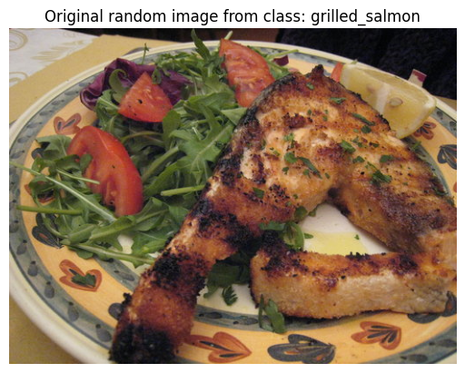

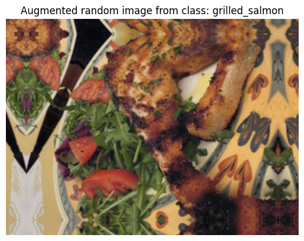

```python
# view a random image
import matplotlib.pyplot as plt
import matplotlib.image as mpimg
import os
import random

target_class = random.choice(train_data_1_percent.class_names) # chooses random class
target_dir = '10_food_classes_1_percent/train/' + target_class # create target directory
random_image = random.choice(os.listdir(target_dir)) # choose a random image from target directory
random_image_path = target_dir + '/' + random_image # create the chosen random image path
img = mpimg.imread(random_image_path) # read in the chosen target image

plt.imshow(img) # plot the target image
plt.title(f'Original random image from class: {target_class}')
plt.axis(False); # turn off the axes

# augment the image
augmented_img = data_augmentation(tf.expand_dims(img, axis=0)) # data augmentation model requires shape (None, height, width, 3)
plt.figure()
plt.imshow(tf.squeeze(augmented_img)/255.) # requires normalization after augmentation
plt.title(f'Augmented random image from class: {target_class}')
plt.axis(False);
```

This gives you an idea of how the image is augmented when ran a few times. This'll apply to each training images when passed through the pretrained model.

This gives more variety for model and reflect real-life when taking photos. Not all pictures will be perfect, so this'll help the model identify more variations of the same class.

Let's build a model with the Functional API. We'll run through similar steps as before, except for a difference > we'll add data augmentation model asa layer, immediately after the input layer.

### Model 1: Feature extraction transfer learning on 1% of the data with data augmentation

```python
# setup input shape and base model, freezing the base model layers
input_shape = (224,224,3)
base_model = tf.keras.applications.efficientnet_v2.EfficientNetV2B0(include_top=False, weights='imagenet', input_shape=input_shape)
base_model.trainable = False

# create input layer
inputs = layers.Input(shape=input_shape, name='input_layer')

# add in data augmentation sequential model as a layer
x = data_augmentation(inputs)

# give base_model inputs (after augmentation) and don't train it
x = base_model(x, training=False)

# pool output features of base model
x = layers.GlobalAveragePooling2D(name='global_average_pooling_layer')(x)

# put a dense layer on as the output
outputs = layers.Dense(10, activation='softmax', name='output_layer')(x)

# make a model with inputs and outputs
model_1 = keras.Model(inputs, outputs)

# compile the model
model_1.compile(loss='categorical_crossentropy',
                optimizer=tf.keras.optimizers.Adam(),
                metrics=['accuracy'])

# fit the model
history_1_percent = model_1.fit(train_data_1_percent,
                                epochs=5,
                                steps_per_epoch=len(train_data_1_percent),
                                validation_data=test_data,
                                validation_steps=int(0.25*len(test_data)), # validate for less steps
                                # track model training logs
                                callbacks=[create_tensorboard_callback('transfer_learning', '1_percent_data_aug')])
```

```
Saving TensorBoard log files to: transfer_learning/1_percent_data_aug/20251006-204956
3/3 ━━━━━━━━━━━━━━━━━━━━ 20s 5s/step - accuracy: 0.1571 - loss: 2.3574 - val_accuracy: 0.1595 - val_loss: 2.2266
3/3 ━━━━━━━━━━━━━━━━━━━━ 7s 3s/step - accuracy: 0.2429 - loss: 2.1532 - val_accuracy: 0.2467 - val_loss: 2.1068
3/3 ━━━━━━━━━━━━━━━━━━━━ 7s 3s/step - accuracy: 0.2857 - loss: 2.0147 - val_accuracy: 0.3405 - val_loss: 1.9988
3/3 ━━━━━━━━━━━━━━━━━━━━ 7s 3s/step - accuracy: 0.4571 - loss: 1.8651 - val_accuracy: 0.4112 - val_loss: 1.9143
3/3 ━━━━━━━━━━━━━━━━━━━━ 7s 3s/step - accuracy: 0.5571 - loss: 1.7401 - val_accuracy: 0.4655 - val_loss: 1.8379
```

Let's check out summary of model. We should see the data augmentation layer just after input layer as well.

```python
# check out model summary
model_1.summary()
```

```
Model: "functional_3"
```

```
┏━━━━━━━━━━━━━━━━━━━━━━━━━━━━━━━━━┳━━━━━━━━━━━━━━━━━━━━━━━━┳━━━━━━━━━━━━━━━┓
┃ Layer (type)                    ┃ Output Shape           ┃       Param # ┃
┡━━━━━━━━━━━━━━━━━━━━━━━━━━━━━━━━━╇━━━━━━━━━━━━━━━━━━━━━━━━╇━━━━━━━━━━━━━━━┩
│ input_layer (InputLayer)        │ (None, 224, 224, 3)    │             0 │
├─────────────────────────────────┼────────────────────────┼───────────────┤
│ data_augmentation (Sequential)  │ (None, None, None, 3)  │             0 │
├─────────────────────────────────┼────────────────────────┼───────────────┤
│ efficientnetv2-b0 (Functional)  │ (None, None, None,     │     5,919,312 │
│                                 │ 1280)                  │               │
├─────────────────────────────────┼────────────────────────┼───────────────┤
│ global_average_pooling_layer    │ (None, 1280)           │             0 │
│ (GlobalAveragePooling2D)        │                        │               │
├─────────────────────────────────┼────────────────────────┼───────────────┤
│ output_layer (Dense)            │ (None, 10)             │        12,810 │
└─────────────────────────────────┴────────────────────────┴───────────────┘
```

```
 Total params: 5,957,744 (22.73 MB)
```

```
 Trainable params: 12,810 (50.04 KB)
```

```
 Non-trainable params: 5,919,312 (22.58 MB)
```

```
 Optimizer params: 25,622 (100.09 KB)
```

Yup the augment layer is there. In case wqe need to save and reload the model, the augmentation layer will come with it.

Important thing to remembert is **data augmentation only runs during training**. So when evaluating our model (aka predicting image class on test data), data augmentation are turned off.

To see that in action, let's evaluate our model on the test data.

```python
# evaluate on the test data
results_1_percent_data_aug = model_1.evaluate(test_data)
results_1_percent_data_aug
```

```
79/79 ━━━━━━━━━━━━━━━━━━━━ 24s 305ms/step - accuracy: 0.4748 - loss: 1.8197
```

```
[1.8197177648544312, 0.4747999906539917]
```

Results may be better or worse when compared to our log, due to how we've only tested the model on 25% of the data by `validation_steps=int(0.25 * len(test_data))`. This helps speed up our epoch training, but still gives a good idea as to our model's performance.

Let's check out the model's loss curves.

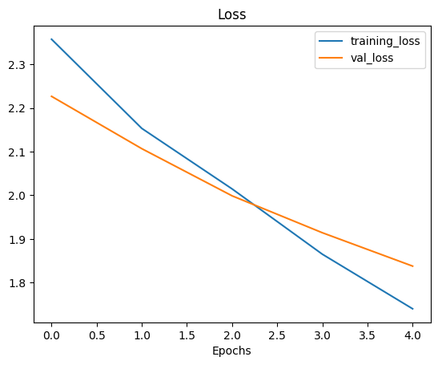

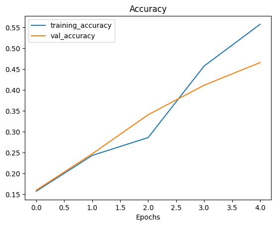

```python
# how does the model fo with a data augmentation layer with 1% of data?
plot_loss_curves(history_1_percent)
```

Based on observation, the model seems to continued to improve on itself if more epochs are trained on them. However we got more experiments to try out and compare first.

### Model 2: Feature extraction transfer learning with 10% of data and data augmentation

Since we've done augmentation under 1% of the data, let's try it on 10% of the data.

> **Question**: How do we know what experiments to run?

You won't know what to run. It's all based on experimentation, trial and error, or curiousity driven. Follow your thoughts and curiousity to the end, and try it out. Worst that can happen is the method doesn't work, and at best gives very valuable knowledge.

To practically run numerous experiments, reduce the amount of time between your experiments, especially on training. Run small epoch trained models, with smaller versions of the same dataset. What's important is to see how well it compares with other experiments.

Once the promising model is found, you can then scale it up to the original dataset.

```python
train_dir_10_percent = '10_food_classes_10_percent/train/'
test_dir = '10_food_classes_10_percent/test/'
```

```python
# setup data inputs
import tensorflow as tf
IMG_SIZE = (224,224)
train_data_10_percent = tf.keras.preprocessing.image_dataset_from_directory(train_dir_10_percent,
                                                                            label_mode='categorical',
                                                                            image_size=IMG_SIZE)

test_data = tf.keras.preprocessing.image_dataset_from_directory(test_dir,
                                                                label_mode='categorical',
                                                                image_size=IMG_SIZE)
```

```
Found 750 files belonging to 10 classes.
Found 2500 files belonging to 10 classes.
```

Let's build a model with data augmentation built into it. You *can* copy paste the augmentation Sequential model, but it's best to manually recreate it.

```python
# create a functional model with data augmentation
import tensorflow as tf
from tensorflow.keras import layers
from tensorflow.keras.models import Sequential

# new TF versions (2.10+) can use tendorflow.keras.layers API directly for data augmentation
data_augmentation = keras.Sequential([
    layers.RandomFlip('horizontal'),
    layers.RandomRotation(0.2),
    layers.RandomZoom(0.2),
    layers.RandomHeight(0.2),
    layers.RandomWidth(0.2),
    # preprocessing.Rescaling(1./255) # keep for ResNet50V2, remove for EfficientNet
], name='data_augmentation')

## OLD
# # Build data augmentation layer
# data_augmentation = Sequential([
#   preprocessing.RandomFlip('horizontal'),
#   preprocessing.RandomHeight(0.2),
#   preprocessing.RandomWidth(0.2),
#   preprocessing.RandomZoom(0.2),
#   preprocessing.RandomRotation(0.2),
#   # preprocessing.Rescaling(1./255) # keep for ResNet50V2, remove for EfficientNet
# ], name="data_augmentation")

# setup the input shape to our model
input_shape = (224,224,3)

# create a frozen base model
# base_model = tf.keras.applications.EfficientNetB0(include_top=False)
base_model = tf.keras.applications.efficientnet_v2.EfficientNetV2B0(include_top=False)
base_model.trainable=False

# create input and output layers
inputs = layers.Input(shape=input_shape, name='input_layer') # create input layer
x = data_augmentation(inputs) # augment our training images
x = base_model(x, training=False) # pass augmented images to base model but keep it in inference mode, so batchnorm layers don't get updated
x = layers.GlobalAveragePooling2D(name='global_average_pooling_layer')(x)
outputs = layers.Dense(10, activation='softmax', name='output_layer')(x)
model_2 = tf.keras.Model(inputs, outputs)

# compile
model_2.compile(loss='categorical_crossentropy',
                optimizer=tf.keras.optimizers.Adam(learning_rate=0.001), # use Adam optimizer with base learning rate
                metrics=['accuracy'])
```

To save time for next time, aka wanting to perform multiple experiments with `model_2`, we can put the above into a function for reuse.

```python
def create_base_model(input_shape: tuple[int,int,int] = (224,224,3),
                      output_shape: int=10,
                      learning_rate: float=0.001,
                      training: bool=False) -> tf.keras.Model:
    '''
    Create a model based on EfficientNetV2B0 with built-in data augmentation.

    Parameters:
    - input_shape (tuple): Expected shape of input images. Default is (224,224,3).
    - output_shape (int): Number of classes for the output layer. Default is 10
    - learning_rate (float): Learning rate for the Adam optimizer. Default is 0.001.
    - training (bool): Whether the base model is trainable. Default is False

    Returns:
    - tf.keras.Model: The compiled model with specified input and output settings.
    '''

    # create base model
    base_model = tf.keras.applications.efficientnet_v2.EfficientNetV2B0(include_top=False)
    base_model.trainable = training

    # Setup model input and outputswith data augmentation built-in
    inputs = layers.Input(shape=input_shape, name='input_layer')
    x = data_augmentation(inputs)
    x = base_model(x, training=False) # pass augmented images to base model but keep it in inference mode
    x = layers.GlobalAveragePooling2D(name='global_average_pooling_layer')(x)
    outputs = layers.Dense(units=output_shape, activation='softmax', name='output_layer')(x)
    model = tf.keras.Model(inputs, outputs)

    # compile model
    model.compile(loss='categorical_crossentropy',
                  optimizer=tf.keras.optimizers.Adam(learning_rate=learning_rate),
                  metrics=['accuracy'])

    return model

# create an instance of model_2 with our new function
model_2 = create_base_model()
```

### Creating a ModelCheckpoint callback

Before fitting model to training data, we have this thing called `ModelCheckpoint` callback.

The `ModelCheckpoint` callback gives you the ability to save your model. The `Savedmodel` format are the weight patterns only, saved into a specified directory while training.

This is especially helpful if training takes too long, and you need to make backups of it during training. This can also mean if you think the model will do better with even longer training period, you can reload it from a specific checkpoint and continue training from there.

E.g. You have a feature extraction model that was trained for 5 epochs. Based on trajectory on its history callback, you think the model will continue to improve further for another 5 epochs. You can then load the checkpoint for the model, and even unfreeze some/all the layers of model and continue training.

And that's what we're gonna do!

Before that, let's create `ModelCheckpoint` callback, and specify a directory to save it to.

```python
# setup checkpoint path
checkpoint_path = "ten_percent_model_checkpoints_weights/checkpoint.weights.h5" # note: remember saving directly to colab is temporary

# create a ModelCheckpoint callback that saves the model's weights only
checkpoint_callback = tf.keras.callbacks.ModelCheckpoint(filepath=checkpoint_path,
                                                         save_weights_only=True, # set to False to save the entire model
                                                         save_best_only=True, # save only the best model weights instead of a model every epoch
                                                         save_freq='epoch', # save every epoch
                                                         verbose=1)
```

> **Questions**: What's the difference between saving the entire model, and saving it's weights only?

The `SavedModel` format saves the model architecture, weights, and training config all in one. It makes it very easy to roload the model elsewhere. With weights itself, you can share it if you don't want all the details of the model to be shared with someone else, or want to save disk space and save faster.

We'll also add in our `checkpoint_callback` in our list of `callbacks`.

```python
# fit the model saving checkpoints every epoch
initial_epochs=5
history_10_percent_data_aug = model_2.fit(train_data_10_percent,
                                          epochs=initial_epochs,
                                          validation_data=test_data,
                                          validation_steps=int(0.25 * len(test_data)), # do less steps per validation (quicker)
                                          callbacks=[create_tensorboard_callback('transfer_learning', '10_percent_data_aug'),
                                                     checkpoint_callback])
```

```
Saving TensorBoard log files to: transfer_learning/10_percent_data_aug/20251006-205113
24/24 ━━━━━━━━━━━━━━━━━━━━ 0s 377ms/step - accuracy: 0.1913 - loss: 2.2321
Epoch 1: val_loss improved from None to 1.55309, saving model to ten_percent_model_checkpoints_weights/checkpoint.weights.h5
24/24 ━━━━━━━━━━━━━━━━━━━━ 28s 781ms/step - accuracy: 0.3120 - loss: 2.0551 - val_accuracy: 0.6727 - val_loss: 1.5531
24/24 ━━━━━━━━━━━━━━━━━━━━ 0s 405ms/step - accuracy: 0.5755 - loss: 1.5684
Epoch 2: val_loss improved from 1.55309 to 1.11007, saving model to ten_percent_model_checkpoints_weights/checkpoint.weights.h5
24/24 ━━━━━━━━━━━━━━━━━━━━ 16s 695ms/step - accuracy: 0.6080 - loss: 1.4725 - val_accuracy: 0.7730 - val_loss: 1.1101
24/24 ━━━━━━━━━━━━━━━━━━━━ 0s 370ms/step - accuracy: 0.7100 - loss: 1.2084
Epoch 3: val_loss improved from 1.11007 to 0.89955, saving model to ten_percent_model_checkpoints_weights/checkpoint.weights.h5
24/24 ━━━━━━━━━━━━━━━━━━━━ 15s 650ms/step - accuracy: 0.7187 - loss: 1.1685 - val_accuracy: 0.8059 - val_loss: 0.8996
24/24 ━━━━━━━━━━━━━━━━━━━━ 0s 377ms/step - accuracy: 0.7401 - loss: 1.0095
Epoch 4: val_loss improved from 0.89955 to 0.78334, saving model to ten_percent_model_checkpoints_weights/checkpoint.weights.h5
24/24 ━━━━━━━━━━━━━━━━━━━━ 16s 657ms/step - accuracy: 0.7307 - loss: 1.0163 - val_accuracy: 0.8043 - val_loss: 0.7833
24/24 ━━━━━━━━━━━━━━━━━━━━ 0s 372ms/step - accuracy: 0.7532 - loss: 0.9251
Epoch 5: val_loss improved from 0.78334 to 0.70671, saving model to ten_percent_model_checkpoints_weights/checkpoint.weights.h5
24/24 ━━━━━━━━━━━━━━━━━━━━ 16s 650ms/step - accuracy: 0.7627 - loss: 0.9040 - val_accuracy: 0.8289 - val_loss: 0.7067
```

The `ModelCheckpoint` callback worked, and saved at every epoch without costing too much time and resources!

Let's evaluate the model and check it's loss curves.

```python
# evaluate on the test data
results_10_percent_data_aug = model_2.evaluate(test_data)
results_10_percent_data_aug
```

```
79/79 ━━━━━━━━━━━━━━━━━━━━ 24s 307ms/step - accuracy: 0.8164 - loss: 0.7025
```

```
[0.7025159597396851, 0.8163999915122986]
```

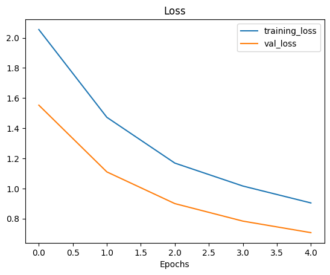

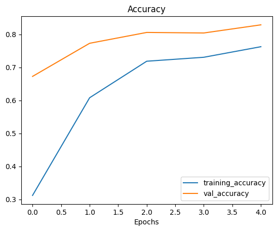

```python
# plot model loss curves
plot_loss_curves(history_10_percent_data_aug)
```

Let's compare the graph to `model_0`, where we trained 10% of data, but had no data augmentation.

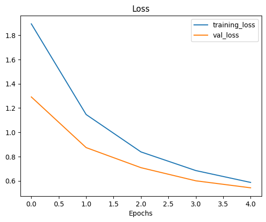

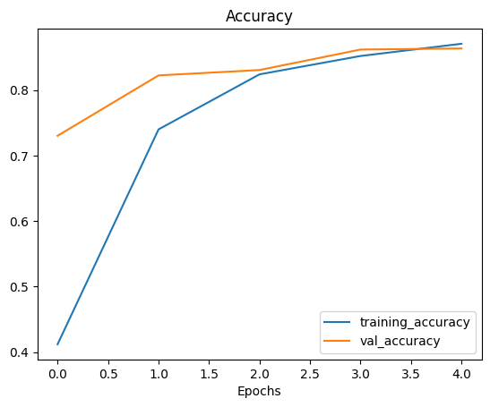

```python
# check out model training curve history
plot_loss_curves(history_10_percent)
```

We can see how adding augmentation on the same amount of data, didn't show as quick of an improvement, as if the data has no augmentation.

However caveat to the problem, is that the `non-augmented` model bottomed and flattened out quickly, as `training` data accuracy, overtook `validation` data accuracy. With `augmented` data, the graph shows as if it has the potential to further improve, with the `validation` accuracy, comfortably sitting above `training` accuracy.

So if we trained augmented some more epochs, it may likely beat the non-augmented model.

Since we've checkpointed the model's weights, we can try load it back in, and test it to see if it saved correctly, by evaluating it on the test data.

To load model weight, you can use `load_weights()` method, passing it the path that saved the model weights.

```python
# load in saved model weights and evaluate model
model_2.load_weights(checkpoint_path)
loaded_weights_model_results = model_2.evaluate(test_data)
```

```
79/79 ━━━━━━━━━━━━━━━━━━━━ 24s 302ms/step - accuracy: 0.8164 - loss: 0.7025
```

Now let's compare the results to previously trained model. They should have very close results, with minor differences only attributed to the precision level/rounding the computer does.

```python
# if the results from our native model and loaded weights are the same, then output should be True
results_10_percent_data_aug == loaded_weights_model_results
```

```
True
```

```python
results_10_percent_data_aug
```

```
[0.7025159597396851, 0.8163999915122986]
```

```python
loaded_weights_model_results
```

```
[0.7025159597396851, 0.8163999915122986]
```

Well it's close enough

```python
import numpy as np
# check to see if loaded model results are very close to native model results (should output True)
np.isclose(np.array(results_10_percent_data_aug), np.array(loaded_weights_model_results))
```

```
array([ True,  True])
```

```python
# check the difference between the two results (small values)
print(np.array(results_10_percent_data_aug) - np.array(loaded_weights_model_results))
```

```
[0. 0.]
```

### Model 3: Fine-tuning an existing model on 10% of the data

[figure not shown]

*High-level example of fine-tuning an EfficientNet model. Bottom layers (the layers next to the input data) stays frozen, where as top layers (the layers next to the output data) are updated bit by bit.*

So far our saved model has been trained using feature extraction transfer learning for 5 epochs on 10% of the training data and data augmentation.

This means all of the layers were frozen during training.

For the next experiment, we're going to use fine-tuning transfer learning. We will use the same base model, except unfreezing some of its layers (closest to the top) and running the model for a few more epochs.

> **Note**: Fine-tuning usually works best *after* training a feature extraction model for a few epochs and with large amounts of data. More info can be checked out here: [Keras' guide on Transfer learning & fine-tuning.](https://keras.io/guides/transfer_learning/)

Let's check out its layers.

```python
# layers in loaded model
model_2.layers
```

```
[<InputLayer name=input_layer, built=True>,
 <Sequential name=data_augmentation, built=True>,
 <Functional name=efficientnetv2-b0, built=True>,
 <GlobalAveragePooling2D name=global_average_pooling_layer, built=True>,
 <Dense name=output_layer, built=True>]
```

How about we check their names, numbers and if they're trainable?

```python
for layer_number, layer in enumerate(model_2.layers):
    print(f'Layer number: {layer_number} | Layer name: {layer} | Layer type: {layer} | Trainable? {layer.trainable}')
```

```
Layer number: 0 | Layer name: <InputLayer name=input_layer, built=True> | Layer type: <InputLayer name=input_layer, built=True> | Trainable? True
Layer number: 1 | Layer name: <Sequential name=data_augmentation, built=True> | Layer type: <Sequential name=data_augmentation, built=True> | Trainable? True
Layer number: 2 | Layer name: <Functional name=efficientnetv2-b0, built=True> | Layer type: <Functional name=efficientnetv2-b0, built=True> | Trainable? False
Layer number: 3 | Layer name: <GlobalAveragePooling2D name=global_average_pooling_layer, built=True> | Layer type: <GlobalAveragePooling2D name=global_average_pooling_layer, built=True> | Trainable? True
Layer number: 4 | Layer name: <Dense name=output_layer, built=True> | Layer type: <Dense name=output_layer, built=True> | Trainable? True
```

We've got an input layer, a Sequential layer (the data augmentation model), a Functional layer (EfficientNetV2B0), a pooling layer and a Dense layer (the output layer).

How about a summary?

```python
model_2.summary()
```

```
Model: "functional_6"
```

```
┏━━━━━━━━━━━━━━━━━━━━━━━━━━━━━━━━━┳━━━━━━━━━━━━━━━━━━━━━━━━┳━━━━━━━━━━━━━━━┓
┃ Layer (type)                    ┃ Output Shape           ┃       Param # ┃
┡━━━━━━━━━━━━━━━━━━━━━━━━━━━━━━━━━╇━━━━━━━━━━━━━━━━━━━━━━━━╇━━━━━━━━━━━━━━━┩
│ input_layer (InputLayer)        │ (None, 224, 224, 3)    │             0 │
├─────────────────────────────────┼────────────────────────┼───────────────┤
│ data_augmentation (Sequential)  │ (None, None, None, 3)  │             0 │
├─────────────────────────────────┼────────────────────────┼───────────────┤
│ efficientnetv2-b0 (Functional)  │ (None, None, None,     │     5,919,312 │
│                                 │ 1280)                  │               │
├─────────────────────────────────┼────────────────────────┼───────────────┤
│ global_average_pooling_layer    │ (None, 1280)           │             0 │
│ (GlobalAveragePooling2D)        │                        │               │
├─────────────────────────────────┼────────────────────────┼───────────────┤
│ output_layer (Dense)            │ (None, 10)             │        12,810 │
└─────────────────────────────────┴────────────────────────┴───────────────┘
```

```
 Total params: 5,957,744 (22.73 MB)
```

```
 Trainable params: 12,810 (50.04 KB)
```

```
 Non-trainable params: 5,919,312 (22.58 MB)
```

```
 Optimizer params: 25,622 (100.09 KB)
```

It looks like the layers in `efficientnetv2-b0` are frozen. We can confirm this using the `trainable_variables` attribute.

> **Note**: The layers of `base_model`, aka `efficientnetv2-b0` of `model_2` is accessible by referencing `model_2.layers[2]`.

```python
# access the base_model layers of model_2
model_2_base_model = model_2.layers[2]
model_2_base_model.name
```

```
'efficientnetv2-b0'
```

```python
# How many layers are trainable in our model_2_base_model?
print(len(model_2_base_model.trainable_variables)) # layer at index 2 is the EfficientNetV2B0 layer (the base model)
```

```
0
```

We can even check layer by layer to see if they're trainable.

To access the layers in `model_2_base_model`, we can use the `layers` attribute.

```python
# check which layer are tuneable (trainable)
for layer_number, layer in enumerate(model_2_base_model.layers):
    print(layer_number, layer.name, layer.trainable)
```

```
0 input_layer_9 False
1 rescaling_6 False
2 normalization_6 False
3 stem_conv False
4 stem_bn False
5 stem_activation False
6 block1a_project_conv False
7 block1a_project_bn False
8 block1a_project_activation False
9 block2a_expand_conv False
10 block2a_expand_bn False
11 block2a_expand_activation False
12 block2a_project_conv False
13 block2a_project_bn False
14 block2b_expand_conv False
```

[output cut: 255 more lines]

Sweet, all are frozen.

Now to fine-tune the model to our data, we will unfreeze the top 10 layers and continue training our model for another 5 epochs. Therefore the remaining layers will be frozen, and not updated during training.

> **Question**: How many layers should you unfreeze when training?

There is no set rule to how much you should unfreeze. Can by one by one layers, or unfreezing the entire model. General rule of thumb, is when you have less training data, you want to unfreeze less layers at a time, and gradually fine tune.

> **Resources**: The [ULMFiT(Universal Lanuage Model Fine-tuning for Text Classification paper)](https://arxiv.org/abs/1801.06146) has a great series of experiments on fine-tuning models.

To begin fine-tuning, we'll unfreeze the entire `model_2_base_model` by setting its `trainable` attribute to `True`.

Then we'll refreeze every layer in `model_2_base_model` except the last 10 by looping through them and setting their `trainable` attribute to `False`.

Finally we'll recompile the whole model.

```python
# Make all the layers in model_2_base_model trainable
model_2_base_model.trainable = True

# freeze all layers except for the last 10
for layer in model_2_base_model.layers[:-10]: # for layers, except the last 10 layers
    layer.trainable = False

# recompile the whole model (always recompile after any adjustments to a model)
model_2.compile(loss='categorical_crossentropy',
                optimizer=tf.keras.optimizers.Adam(learning_rate=0.0001), # lr is 10x lower than before for fine-tuning
                metrics=['accuracy'])
```

Now let's check which layers of the pretrained model are trainable.

```python
# check which layer are tuneable (trainable)
for layer_number, layer in enumerate(model_2_base_model.layers):
    print(layer_number, layer.name, layer.trainable)
```

```
0 input_layer_9 False
1 rescaling_6 False
2 normalization_6 False
3 stem_conv False
4 stem_bn False
5 stem_activation False
6 block1a_project_conv False
7 block1a_project_bn False
8 block1a_project_activation False
9 block2a_expand_conv False
10 block2a_expand_bn False
11 block2a_expand_activation False
12 block2a_project_conv False
13 block2a_project_bn False
14 block2b_expand_conv False
```

[output cut: 255 more lines]

Nice the last 10 layers are unfrozened!

> **Question**: Why did we recompile the model?

Every time you make a change to the base model's architecture/trainable parameters, you would need to recompile them.

For our case, our loss, optimizer, and metrics are the same as before. Not the learning rate, which is 10x smaller than before.

We shrink `Adam` so the model doesn't try overwriting existing weights in the pretrained model too quickly. Basically, we want learning to be more gradual.

> **Note**: There's no set standard for setting the learning rate during fine-tuning, though reductions of [2.6x-10x+ seem to work well in practice.](https://arxiv.org/abs/1801.06146)

How many trainable variables do we have now?

```python
print(len(model_2.trainable_variables))
```

```
12
```

It looks we have 12 trainable variables. The 10 layers of base model, in addition to the weight and bias parameters of the Dense layer output.

Time to fine tune :)

From `Model_2`, we've already done 5 epochs worth of training on it. We will continue where it left off, and train another 5 epochs.

```python
# fine tune for another 5 epochs
fine_tune_epochs = initial_epochs + 5

# refit the model (same as mode_2 but more trainable layers)
history_fine_10_percent_data_aug = model_2.fit(train_data_10_percent,
                                          epochs=fine_tune_epochs,
                                          validation_data=test_data,
                                          initial_epoch=history_10_percent_data_aug.epoch[-1], # start from previous last epoch
                                          validation_steps=int(0.25 * len(test_data)),
                                          callbacks=[create_tensorboard_callback('transfer_learning','10_percent_fine_tune_last_10')]) # name the experiment accordingly
```

```
Saving TensorBoard log files to: transfer_learning/10_percent_fine_tune_last_10/20251006-205334
24/24 ━━━━━━━━━━━━━━━━━━━━ 30s 771ms/step - accuracy: 0.7533 - loss: 1.0031 - val_accuracy: 0.8240 - val_loss: 0.7592
24/24 ━━━━━━━━━━━━━━━━━━━━ 15s 656ms/step - accuracy: 0.7800 - loss: 0.9083 - val_accuracy: 0.8487 - val_loss: 0.6563
24/24 ━━━━━━━━━━━━━━━━━━━━ 16s 661ms/step - accuracy: 0.7787 - loss: 0.8607 - val_accuracy: 0.8520 - val_loss: 0.6279
24/24 ━━━━━━━━━━━━━━━━━━━━ 16s 660ms/step - accuracy: 0.8147 - loss: 0.7854 - val_accuracy: 0.8602 - val_loss: 0.5753
24/24 ━━━━━━━━━━━━━━━━━━━━ 17s 703ms/step - accuracy: 0.8013 - loss: 0.7408 - val_accuracy: 0.8569 - val_loss: 0.5507
24/24 ━━━━━━━━━━━━━━━━━━━━ 16s 674ms/step - accuracy: 0.8133 - loss: 0.7238 - val_accuracy: 0.8536 - val_loss: 0.5182
```

> **Note**: Fine tuning usually takes a lot longer than feature extraction, as model has to update more weights throughout the model.

Our model has done some percentage better now. Let's evaluate it.

```python
# Evaluate the model on the test data
results_fine_tune_10_percent = model_2.evaluate(test_data)
```

```
79/79 ━━━━━━━━━━━━━━━━━━━━ 24s 304ms/step - accuracy: 0.8460 - loss: 0.5296
```

We need a way to evaluate model performance 'before' and 'after' tuning. How about we write a function to compare before and after?

```python
def compare_history(original_history, new_history, initial_epochs=5):
    '''
    compare two model history objects
    '''
    # get original history measurements
    acc = original_history.history['accuracy']
    loss = original_history.history['loss']

    print(len(acc))

    val_acc = original_history.history['val_accuracy']
    val_loss = original_history.history['val_loss']

    # combine original history with new history
    total_acc = acc + new_history.history['accuracy']
    total_loss = loss + new_history.history['loss']

    total_val_acc = val_acc + new_history.history['val_accuracy']
    total_val_loss = val_loss + new_history.history['val_loss']

    print(len(total_acc))
    print(total_acc)

    # make plots
    plt.figure(figsize=(8,8))
    plt.subplot(2,1,1)
    plt.plot(total_acc, label='Training Accuracy')
    plt.plot(total_val_acc, label='Validation Accuracy')
    plt.plot([initial_epochs-1, initial_epochs-1],
             plt.ylim(), label='Start Fine Tuning') # creates boundary line between `model_2` and `model_3`
    plt.legend(loc='lower right')
    plt.title('Training and Validation accuracy')

    plt.subplot(2,1,2)
    plt.plot(total_loss, label='Training Loss')
    plt.plot(total_val_loss, label='Validation Loss')
    plt.plot([initial_epochs-1, initial_epochs-1],
             plt.ylim(), label='Start Fine Tuning') # creates boundary line between `model_2` and `model_3`
    plt.legend(loc='upper right')
    plt.title('Training and Validation Loss')
    plt.xlabel('epoch')
    plt.show()
```

This is where saving the history variables of our model training comes handy. Let's see what happened after fine-tuning the last 10 layers of our model.

```
5
11
[0.31200000643730164, 0.6079999804496765, 0.718666672706604, 0.7306666374206543, 0.762666642665863, 0.753333330154419, 0.7799999713897705, 0.7786666750907898, 0.8146666884422302, 0.8013333082199097, 0.8133333325386047]
```

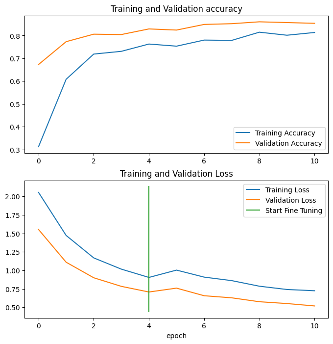

```python
compare_history(original_history=history_10_percent_data_aug,
                new_history=history_fine_10_percent_data_aug,
                initial_epochs=5)
```

The model flattened out quite quickly, however some amount of progress is still made.

### Model 4: Fine-tuning an existing model all of the data

Let' try fine tuning but with entire dataset of 10 food classes.

```python
# setup data directories
train_dir = '10_food_classes_all_data/train/'
test_dir = test_dir
```

```python
# how many images are we working with?
walk_through_dir('10_food_classes_all_data'), walk_through_dir('10_food_classes_10_percent/test')
```

```
There are 1 directories and 0 images in '10_food_classes_all_data'.
There are 10 directories and 0 images in '10_food_classes_all_data\train'.
There are 0 directories and 750 images in '10_food_classes_all_data\train\ice_cream'.
There are 0 directories and 750 images in '10_food_classes_all_data\train\chicken_curry'.
There are 0 directories and 750 images in '10_food_classes_all_data\train\steak'.
There are 0 directories and 750 images in '10_food_classes_all_data\train\sushi'.
There are 0 directories and 750 images in '10_food_classes_all_data\train\chicken_wings'.
There are 0 directories and 750 images in '10_food_classes_all_data\train\grilled_salmon'.
There are 0 directories and 750 images in '10_food_classes_all_data\train\hamburger'.
There are 0 directories and 750 images in '10_food_classes_all_data\train\pizza'.
There are 0 directories and 750 images in '10_food_classes_all_data\train\ramen'.
There are 0 directories and 750 images in '10_food_classes_all_data\train\fried_rice'.
There are 10 directories and 0 images in '10_food_classes_10_percent/test'.
There are 0 directories and 250 images in '10_food_classes_10_percent/test\ice_cream'.
There are 0 directories and 250 images in '10_food_classes_10_percent/test\chicken_curry'.
There are 0 directories and 250 images in '10_food_classes_10_percent/test\steak'.
There are 0 directories and 250 images in '10_food_classes_10_percent/test\sushi'.
There are 0 directories and 250 images in '10_food_classes_10_percent/test\chicken_wings'.
There are 0 directories and 250 images in '10_food_classes_10_percent/test\grilled_salmon'.
There are 0 directories and 250 images in '10_food_classes_10_percent/test\hamburger'.
There are 0 directories and 250 images in '10_food_classes_10_percent/test\pizza'.
There are 0 directories and 250 images in '10_food_classes_10_percent/test\ramen'.
There are 0 directories and 250 images in '10_food_classes_10_percent/test\fried_rice'.
```

```
(None, None)
```

```python
# setup data inputs
import tensorflow as tf
IMG_SIZE = (224,224)
train_data_10_classes_full = tf.keras.preprocessing.image_dataset_from_directory(train_dir,
                                                                                 label_mode='categorical',
                                                                                 image_size=IMG_SIZE)

# note: this is the same test we've been using for the previous modelling experiments
test_data = tf.keras.preprocessing.image_dataset_from_directory(test_dir,
                                                                label_mode='categorical',
                                                                image_size=IMG_SIZE)
```

```
Found 7500 files belonging to 10 classes.
Found 2500 files belonging to 10 classes.
```

We got the same test set, but now 10x the training data.

Our `model_2` has been fine tuned on 10 percent of data, so to begin fine-tuning on all the data and keep experiments consistent, we need to recert it back to weights we checkpointed at epoch 5, during feature extraction.

To demonstate this, we'll first evaluate the current `model_2`.

```python
# evaluate model (this is the fine tuned 10 percent)
model_2.evaluate(test_data)
```

```
79/79 ━━━━━━━━━━━━━━━━━━━━ 24s 307ms/step - accuracy: 0.8460 - loss: 0.5296
```

```
[0.529642641544342, 0.8460000157356262]
```

These are the same values as `results_fine_tune_10_percent` (as we've created a variable to it when evaluating it)

```python
results_fine_tune_10_percent
```

```
[0.5296427607536316, 0.8460000157356262]
```

To keep our experiments clean, we'll create a new instance of `model_2` using `create_base_model()` function.

More specifically, we're trying to measure:

- **Experiment 3 (previous one)** - `model_2` with 10 layers fine-tuned for 5 more epochs on 10% of the data.
- **Experiment 4 (this one)** - `model_2` with layers fined-tuned for 5 more epochs on 100% of the data.

Both experiments, are using the same test data to allow comparison of results.

Plus, they should start from the same checkpoint (from `model_2's` feature extractor trained for 5 epochs on 10% of the data).

Let's first create new instance of `model_2`.

```python
# create a new instance of model_2 for Experiment 4
model_2 = create_base_model(learning_rate=0.0001) # x10 lower learning rate for fine-tuning, like experiment 3
```

And now o make sure it starts at the same checkpoint, we can load the checkpointed weights from `checkpoint_path`.

```python
# load previously checkpointed weights
model_2.load_weights(checkpoint_path)
```

Let's now get a summary and check how many trainable variables there are.

```python
model_2.summary()
```

```
Model: "functional_7"
```

```
┏━━━━━━━━━━━━━━━━━━━━━━━━━━━━━━━━━┳━━━━━━━━━━━━━━━━━━━━━━━━┳━━━━━━━━━━━━━━━┓
┃ Layer (type)                    ┃ Output Shape           ┃       Param # ┃
┡━━━━━━━━━━━━━━━━━━━━━━━━━━━━━━━━━╇━━━━━━━━━━━━━━━━━━━━━━━━╇━━━━━━━━━━━━━━━┩
│ input_layer (InputLayer)        │ (None, 224, 224, 3)    │             0 │
├─────────────────────────────────┼────────────────────────┼───────────────┤
│ data_augmentation (Sequential)  │ (None, None, None, 3)  │             0 │
├─────────────────────────────────┼────────────────────────┼───────────────┤
│ efficientnetv2-b0 (Functional)  │ (None, None, None,     │     5,919,312 │
│                                 │ 1280)                  │               │
├─────────────────────────────────┼────────────────────────┼───────────────┤
│ global_average_pooling_layer    │ (None, 1280)           │             0 │
│ (GlobalAveragePooling2D)        │                        │               │
├─────────────────────────────────┼────────────────────────┼───────────────┤
│ output_layer (Dense)            │ (None, 10)             │        12,810 │
└─────────────────────────────────┴────────────────────────┴───────────────┘
```

```
 Total params: 5,932,122 (22.63 MB)
```

```
 Trainable params: 12,810 (50.04 KB)
```

```
 Non-trainable params: 5,919,312 (22.58 MB)
```

```python
print(len(model_2.trainable_variables))
```

```
2
```

This should now be the same as the original model_2 before fine tuning.

Results should be the same as `results_10_percent_data_aug`.

```python
# After loading in weights, the values should have gone back down (due to no fine-tuning).
model_2.evaluate(test_data)
```

```
79/79 ━━━━━━━━━━━━━━━━━━━━ 29s 311ms/step - accuracy: 0.8164 - loss: 0.7025
```

```
[0.7025160193443298, 0.8163999915122986]
```

So the steps we've taken to reach here are:

1. Trained a feature extraction transfer learning model for 5 epochs on 10% of the data (base model entirely frozen), and saved a checkpoint of the model's weights .
2. Fine-tuned the same model on the same 10% of data, but for continuing on another 5 epochs, with the top 10 layers of base model being unfrozened.
3. Saved the results and training logs per epoch.
4. Reloaded `model_2` from when it did 5 epochs, and did step 2 with 100% of data, instead of 10%.

So we'll fine-tune the top 10 layers again for another 5 epochs on 100% of the data. But first, let's remind ourselves which layers are trainable.

```python
# check which layers are tuneable in the whole model
for layer_number, layer in enumerate(model_2.layers):
    print(layer_number, layer.name, layer.trainable)
```

```
0 input_layer True
1 data_augmentation True
2 efficientnetv2-b0 False
3 global_average_pooling_layer True
4 output_layer True
```

Remember that our base model `model_2`, can be referenced via it's index locality such as `model_2.layers[2]`.

So let's unfreeze the last 10 layers of `base_model` to make them trainable (aka. fine tune).

```python
# unfreeze the top 10 layers in model_2's base model
model_2_base_model = model_2.layers[2]
model_2_base_model.trainable = True

# freeze all layers except for the last 10
for layer in model_2_base_model.layers[:-10]:
    layer.trainable = False
```

Now let's make sure the right layers are trainable.

> **Note**: You could experiment which number of layers should be trainable here. Generally, the more data you have, the more layers you can fine-tune to account for it.

```python
# Check which layers are tuneable in the base model
for layer_number, layer in enumerate(model_2_base_model.layers):
    print(layer_number, layer.name, layer.trainable)
```

```
0 input_layer_10 False
1 rescaling_7 False
2 normalization_7 False
3 stem_conv False
4 stem_bn False
5 stem_activation False
6 block1a_project_conv False
7 block1a_project_bn False
8 block1a_project_activation False
9 block2a_expand_conv False
10 block2a_expand_bn False
11 block2a_expand_activation False
12 block2a_project_conv False
13 block2a_project_bn False
14 block2b_expand_conv False
```

[output cut: 255 more lines]

Looks like our 10 last layers are trainable.

Now to recompile the model, so that our changes to the model is set.

```python
# recompile the model (always recompile after any adjustments to a model)
model_2.compile(loss='categorical_crossentropy',
                optimizer=tf.keras.optimizers.Adam(learning_rate=0.0001), # lr 10x lower for better fine tuning
                metrics=['accuracy'])
```

Alright, time to fine-tune data :)

```python
# continue to train and fine-tune the model to our data
fine_tune_epochs = initial_epochs+5

history_fine_10_classes_full = model_2.fit(train_data_10_classes_full,
                                           epochs=fine_tune_epochs,
                                           initial_epoch=history_10_percent_data_aug.epoch[-1],
                                           validation_data=test_data,
                                           validation_steps=int(0.25 * len(test_data)),
                                           callbacks=[create_tensorboard_callback('transfer_learning','full_10_classes_fine_tune_last_10')])
```

```
Saving TensorBoard log files to: transfer_learning/full_10_classes_fine_tune_last_10/20251006-220237
235/235 ━━━━━━━━━━━━━━━━━━━━ 139s 543ms/step - accuracy: 0.7387 - loss: 0.9286 - val_accuracy: 0.8520 - val_loss: 0.4477
235/235 ━━━━━━━━━━━━━━━━━━━━ 143s 607ms/step - accuracy: 0.7877 - loss: 0.7272 - val_accuracy: 0.8832 - val_loss: 0.3469
235/235 ━━━━━━━━━━━━━━━━━━━━ 132s 564ms/step - accuracy: 0.8053 - loss: 0.6441 - val_accuracy: 0.8947 - val_loss: 0.3118
235/235 ━━━━━━━━━━━━━━━━━━━━ 131s 560ms/step - accuracy: 0.8119 - loss: 0.6017 - val_accuracy: 0.9145 - val_loss: 0.2662
235/235 ━━━━━━━━━━━━━━━━━━━━ 133s 568ms/step - accuracy: 0.8260 - loss: 0.5621 - val_accuracy: 0.9112 - val_loss: 0.2741
235/235 ━━━━━━━━━━━━━━━━━━━━ 132s 563ms/step - accuracy: 0.8320 - loss: 0.5356 - val_accuracy: 0.9112 - val_loss: 0.2673
```

> **Note**: Training took wayyy longer, because we are using 10x more data for training

Let's evaluate the test data

```python
results_fine_tune_full_data = model_2.evaluate(test_data)
results_fine_tune_full_data
```

```
79/79 ━━━━━━━━━━━━━━━━━━━━ 31s 391ms/step - accuracy: 0.9156 - loss: 0.2604
```

```
[0.26041892170906067, 0.9156000018119812]
```

```python
results_fine_tune_10_percent
```

```
[0.5296427607536316, 0.8460000157356262]
```

It looks like our fine-tuning on full training data has given the model's accuracy a bit of a boost!

```
5
11
[0.31200000643730164, 0.6079999804496765, 0.718666672706604, 0.7306666374206543, 0.762666642665863, 0.7386666536331177, 0.7877333164215088, 0.8053333163261414, 0.8118666410446167, 0.8259999752044678, 0.8320000171661377]
```

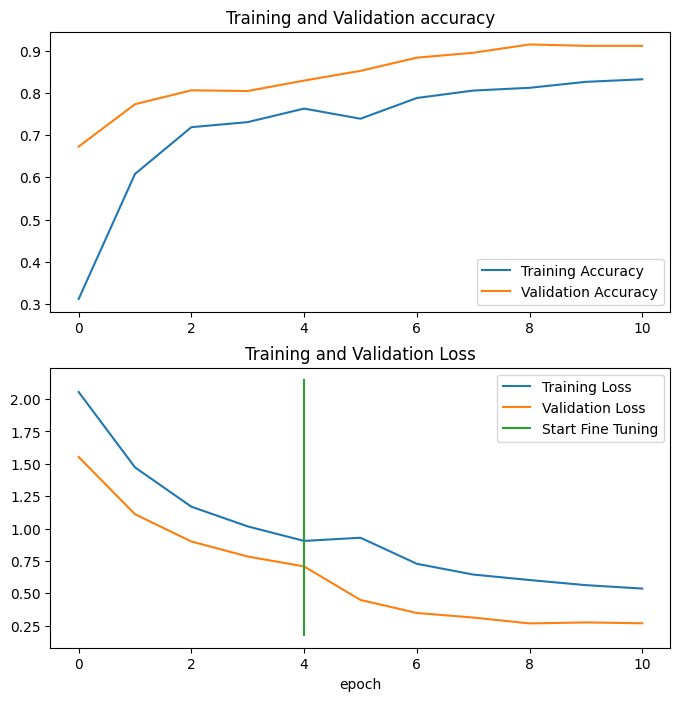

```python
# how did fine-tuning go with more data?
compare_history(original_history=history_10_percent_data_aug,
                new_history=history_fine_10_classes_full,
                initial_epochs=5)
```

Seems like that extra data has helped edge out a bit! If trained for long, the model will most likely keep improving.

### 🛠 Exercises

1. Write a function to visualize an image from any dataset (train or test file) and any class (e.g. "steak", "pizza"... etc), visualize it and make a prediction on it using a trained model.
2. Use feature-extraction to train a transfer learning model on 10% of the Food Vision data for 10 epochs using tf.keras.applications.efficientnet_v2.EfficientNetV2B0 as the base model. Use the ModelCheckpoint callback to save the weights to file.
3. Fine-tune the last 20 layers of the base model you trained in 2 for another 10 epochs. How did it go?
4. Fine-tune the last 30 layers of the base model you trained in 2 for another 10 epochs. How did it go?

### 📖 Extra-curriculum

1. Read the documentation on data augmentation in TensorFlow.
2. Read the ULMFit paper (technical) for an introduction to the concept of freezing and unfreezing different layers.
3. Read up on learning rate scheduling (there's a TensorFlow callback for this), how could this influence our model training?
4. If you're training for longer, you probably want to reduce the learning rate as you go... the closer you get to the bottom of the hill, the smaller steps you want to take. Imagine it like finding a coin at the bottom of your couch. In the beginning your arm movements are going to be large and the closer you get, the smaller your movements become.